# bayesQRsurvey

bayesQRsurvey Package

2025-09-26

## Introduction

[figure not shown]

[figure not shown]

The **bayesQRsurvey** package implements four approaches for Bayesian weighted quantile regression:

- **Asymmetric Laplace Distribution (ALD)**: Uses the ALD as a working likelihood, incorporating survey weights in the scale parameter. Posterior inference is carried out via Gibbs sampling.
- **Score**: Builds a working likelihood from estimating equations (score function), following Huang, Xu and Tashnev (2015). It accounts for survey weights and uses adaptive Metropolis–Hastings for inference.
- **Approximate**: Proposed by Wang, Kim and Yang (2018), this method approximates the posterior using the sampling distribution of summary statistics. The Score-based method is a special case, also using adaptive Metropolis–Hastings.
- **Expectation–Maximization (EM) Algorithm**: Implemented for multivariate quantile regression. It leverages the ALD mixture representation to update latent variables and parameters iteratively, targeting posterior modes with much lower computational cost than MCMC.

Also, this vignette compares the performance of **bayesQR** with the three MCMC methods implemented in **bayesQRsurvey** using a simulated dataset and the classic Prostate cancer dataset included in the `bayesQR` package.  
We estimate the 25th, 50th, and 75th quantile and compare coefficient estimates across all methods.

## bayesQRsurvey usage examples

Let’s begin showing how to use bayesQRsurvey methods:

```r
library(bayesQRsurvey)
```

### Creating Priors

The `prior()` function provides a unified interface to define prior distributions for both **univariate** (`bqr.svy`) and **multivariate** (`mo.bqr.svy`) Bayesian quantile regression models.

It returns an **S3 object** that store the prior information in a structured way.

> The `prior()` function creates an S3 object of class `bqr_prior` that contains the prior information. If the object is omitted in a call to `bqr.svy()` or `mo.bqr.svy()`, a **standard vague prior** is used by default.

Doing an example using bayesQRsurvey

```r
my_prior <- bayesQRsurvey::prior(
  beta_x_mean = rep(0, 4),
  beta_x_cov  = diag(1000, 4),
  sigma_shape = 0.001,
  sigma_rate  = 0.001
)

print(my_prior)
```

```
#> Prior  beta_x_mean: 0 0 0 0
#>   beta_x_cov:
#>      [,1] [,2] [,3] [,4]
#> [1,] 1000    0    0    0
#> [2,]    0 1000    0    0
#> [3,]    0    0 1000    0
#> [4,]    0    0    0 1000
#>   sigma IG:    shape=0.001, rate=0.001
#>   beta_y_mean: diffuse (all zeros)
#>   beta_y_cov:  diffuse (large diagonal: 1e6)
```

### Fitting models with different methods

We use the **mtcars** dataset to fit three models — **ALD**, **Score**, and **Approximate** — each at the 0.5 quantile.

```r
set.seed(123)

data(mtcars)

mtcars_scaled <- mtcars
mtcars_scaled[, c("wt", "hp", "cyl")] <- scale(mtcars[, c("wt", "hp", "cyl")])

form <- mpg ~ wt + hp + cyl

fit_ald <- bqr.svy(
  form,
  data      = mtcars_scaled,
  quantile  = 0.5,
  method    = "ald",
  niter     = 20000,
  burnin    = 10000,
  thin      = 5,
  prior     = my_prior,
  verbose   = TRUE
)
```

```
#> Iteration 2000 of 20000
#> Iteration 4000 of 20000
#> Iteration 6000 of 20000
#> Iteration 8000 of 20000
#> Iteration 10000 of 20000
#> Iteration 12000 of 20000
#> Iteration 14000 of 20000
#> Iteration 16000 of 20000
#> Iteration 18000 of 20000
```

```r
fit_score <- bqr.svy(
  form,
  data      = mtcars_scaled,
  quantile  = 0.5,
  method    = "score",
  niter     = 20000,
  burnin    = 10000,
  prior     = my_prior,
  thin      = 5,
  verbose   = TRUE
)
```

```
#> Iteration 2000 of 20000
#> Iteration 4000 of 20000
#> Iteration 6000 of 20000
#> Iteration 8000 of 20000
#> Iteration 10000 of 20000
#> Iteration 12000 of 20000
#> Iteration 14000 of 20000
#> Iteration 16000 of 20000
#> Iteration 18000 of 20000
#> Iteration 20000 of 20000
```

```r
fit_approx <- bqr.svy(
  form,
  data      = mtcars_scaled,
  quantile  = 0.5,
  method    = "approximate",
  niter     = 20000,
  burnin    = 10000,
  prior     = my_prior,
  thin      = 5,
  verbose   = TRUE
)
```

```
#> Iteration 0 of 20000
#> Iteration 2000 of 20000
#> Iteration 4000 of 20000
#> Iteration 6000 of 20000
#> Iteration 8000 of 20000
#> Iteration 10000 of 20000
#> Iteration 12000 of 20000
#> Iteration 14000 of 20000
#> Iteration 16000 of 20000
#> Iteration 18000 of 20000
```

For the EM algorithm, the model is fitted by projecting the multivariate response onto a set of directions. These directions can be supplied by the user through an object `U`; if not provided, the algorithm will automatically generate them.

```r
data(mtcars)

Y <- cbind(mtcars$mpg, mtcars$hp)

set.seed(123)
d <- ncol(Y)
n_dir <- 3
U <- matrix(NA_real_, d, n_dir)
for (k in 1:n_dir) {
  u_k <- rnorm(d)
  U[, k] <- u_k / sqrt(sum(u_k^2))
}

fit_mo <- mo.bqr.svy(
  cbind(mpg, hp) ~ wt + cyl + disp,
  data     = mtcars,
  quantile = c(0.25, 0.5, 0.75),
  U        = U,
  prior    = my_prior,
  n_dir    = n_dir,
  max_iter = 5000,
  verbose  = FALSE
)


gamma_U <- vector("list", n_dir)
for (k in 1:n_dir) {
  gamma_U[[k]] <- pracma::nullspace(t(U[, k]))
}

fit_mo <- mo.bqr.svy(
  cbind(mpg, hp) ~ wt + cyl + disp,
  data     = mtcars,
  quantile = c(0.25, 0.5, 0.75),
  U        = U,
  gamma_U  = gamma_U,
  prior    = my_prior,
  n_dir    = n_dir,
  max_iter = 5000,
  verbose  = FALSE
)
```

We can also fit several quantiles at once by passing a vector of probabilities with `c()`, for example `quantile = c(0.25, 0.5, 0.75)`.

### Model Output: Print and Summary Methods

There are also print() and summary() created for the output objects of bayesQRsurvey

We can explore the return of the object bqr.svy

```r
# Print method - shows basic model information
knitr::kable(
  data.frame(
    Information = c("Method", "Quantiles", "Draws", "Burn-in", "Thin"),
    Value = c(fit_ald$method,
              paste(fit_ald$quantile, collapse = ", "),
              length(fit_ald$draws),
              fit_ald$warmup,
              fit_ald$thin)
  ),
  caption = "Model Information - ALD Method"
)
```

Model Information - ALD Method

| Information | Value |
| --- | --- |
| Method | ald |
| Quantiles | 0.5 |
| Draws | 10000 |
| Burn-in | 10000 |
| Thin | 5 |

```r
# Summary method - detailed convergence diagnostics will be shown in summary section

# Access posterior draws - show structure
if (!is.null(fit_ald$draws)) {
  knitr::kable(
    head(as.data.frame(fit_ald$draws), 6),
    caption = "First 6 posterior draws (ALD Method)",
    digits = 4
  )
}
```

First 6 posterior draws (ALD Method)

| (Intercept) | wt | hp | cyl | sigma |
| --- | --- | --- | --- | --- |
| 19.5491 | -3.4376 | -1.0179 | -1.5954 | 0.7238 |
| 19.4543 | -2.5142 | -0.7504 | -2.4742 | 0.7828 |
| 19.5965 | -2.6978 | -0.5379 | -2.8920 | 0.6449 |
| 19.5514 | -2.7159 | -0.3566 | -2.6491 | 0.5281 |
| 19.4124 | -3.1352 | -0.5566 | -2.1270 | 0.8342 |
| 19.4756 | -2.9804 | -0.8045 | -2.3303 | 0.7001 |

For the `mo.bqr.svy` it is recommended to use the `summary()` method in order to obtain a cleaner and more structured view of the output. This provides posterior mode estimates, EM convergence information, and scale parameters for each quantile and direction.

### Convergence Diagnostics

```r
methods <- c("ALD", "Score", "Approximate")
fits <- list(fit_ald, fit_score, fit_approx)

summ_multi <- lapply(fits, summary)

summ_df <- do.call(rbind, lapply(seq_along(summ_multi), function(i) {
  s <- summ_multi[[i]]
  if (!is.null(s$posterior_summary)) {
    df <- as.data.frame(s$posterior_summary)
  } else if (!is.null(s$per_tau)) {
    df <- as.data.frame(s$per_tau[[1]]$coef_summary)
  } else {
    stop("Unexpected summary object structure")
  }
  df$Method <- methods[i]
  df
}))

summ_df <- summ_df[, c("Method", setdiff(names(summ_df), "Method"))]

knitr::kable(
  summ_df,
  caption = "Posterior summary for all methods (Quantile = 0.5)",
  digits = 3
)
```

Posterior summary for all methods (Quantile = 0.5)

| Method | variable | mean | median | sd | rhat | ess_bulk | ess_tail | q2.5 | q97.5 | lower_ci | upper_ci |
| --- | --- | --- | --- | --- | --- | --- | --- | --- | --- | --- | --- |
| ALD | (Intercept) | 19.469 | 19.462 | 0.191 | 1.000 | 1284.050 | 1346.805 | 19.115 | 19.900 | 19.115 | 19.900 |
| ALD | wt | -2.812 | -2.813 | 0.286 | 1.000 | 1358.121 | 1665.570 | -3.369 | -2.268 | -3.369 | -2.268 |
| ALD | hp | -0.843 | -0.790 | 0.478 | 1.000 | 933.397 | 994.624 | -1.932 | -0.084 | -1.932 | -0.084 |
| ALD | cyl | -2.272 | -2.277 | 0.553 | 1.001 | 1059.654 | 1155.988 | -3.292 | -1.142 | -3.292 | -1.142 |
| Score | (Intercept) | 19.479 | 19.454 | 0.099 | 1.097 | 27.884 | 46.723 | 19.355 | 19.749 | 19.355 | 19.749 |
| Score | wt | -2.814 | -2.820 | 0.128 | 1.015 | 58.352 | 55.550 | -3.096 | -2.586 | -3.096 | -2.586 |
| Score | hp | -0.820 | -0.741 | 0.361 | 1.132 | 17.219 | 20.535 | -1.904 | -0.374 | -1.904 | -0.374 |
| Score | cyl | -2.233 | -2.276 | 0.323 | 1.141 | 16.421 | 20.878 | -2.816 | -1.290 | -2.816 | -1.290 |
| Approximate | (Intercept) | 19.485 | 19.459 | 0.088 | 1.050 | 59.662 | 296.791 | 19.370 | 19.693 | 19.370 | 19.693 |
| Approximate | wt | -2.791 | -2.795 | 0.103 | 1.004 | 253.814 | 451.323 | -2.970 | -2.603 | -2.970 | -2.603 |
| Approximate | hp | -0.682 | -0.712 | 0.184 | 1.070 | 69.906 | 143.035 | -0.922 | -0.303 | -0.922 | -0.303 |
| Approximate | cyl | -2.399 | -2.345 | 0.235 | 1.036 | 81.944 | 167.684 | -2.989 | -2.094 | -2.989 | -2.094 |

### Visualization functions

The `bayesQRsurvey` package provides comprehensive visualization capabilities through its `plot()` method. The plotting system supports both **base R graphics** (default) and **ggplot2** (when `use_ggplot = TRUE`).

#### 1-. Fitted regression plot

Example plotting the fitted regression line using **ggplot2**, including the credible interval as a shaded band around the fitted line.

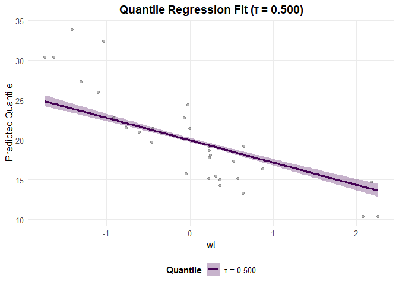

```r
plot(fit_ald, use_ggplot = TRUE, show_ci  =TRUE)
```

It is possible to hide the points from the plot by setting the argument `add_points = FALSE`.

#### 2. Trace Plots

Example plotting the MCMC trace of a selected coefficient to assess convergence and mixing across iterations.

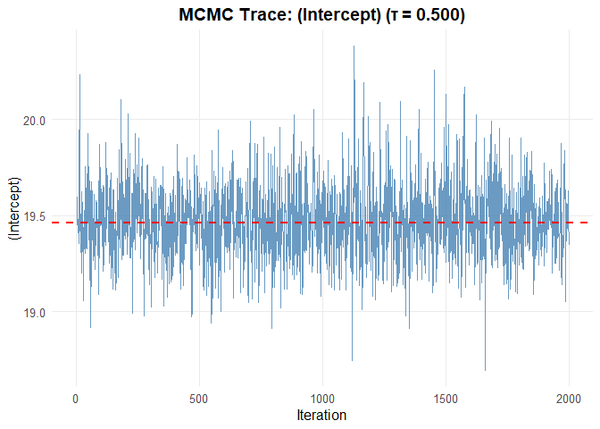

```r
# Basic quantile plot (requires x_var)
plot(fit_ald, type = "trace", x_var = "hp")
```

#### 3. Density Plots

Example plotting the posterior density of a selected coefficient, including the fitted quantile as a reference line.

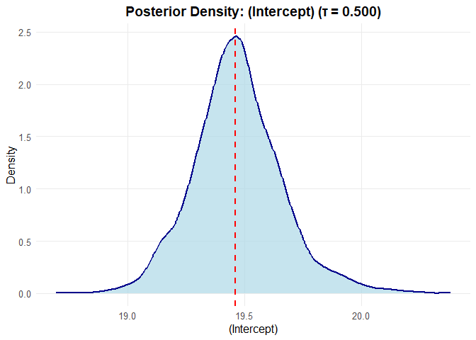

```r
# Combined view
plot(fit_ald, type = "density", x_var = "wt")
```

#### 4. Quantile Plots

Example plotting the estimated coefficient of a predictor across multiple quantiles.

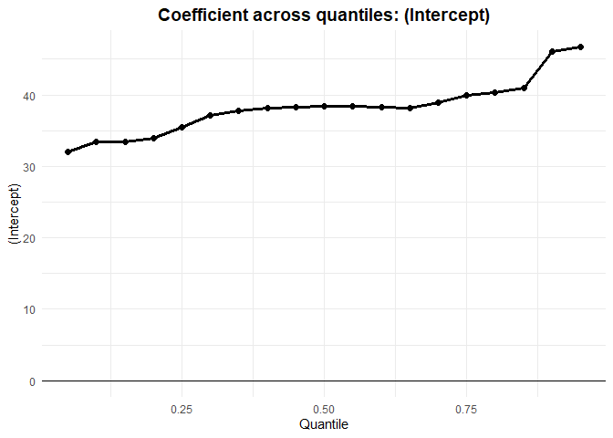

```r
fit_multi <- bqr.svy(
  mpg ~ wt + hp + cyl,
  data = mtcars,
  quantile = seq(0.05, 0.95, 0.05),
  method = "ald",
  niter = 10000,
  burnin = 5000,
  thin = 5,
  verbose  = FALSE
)

plot(fit_multi, type = "quantile", which = "(Intercept)")
```

#### 5. Multi-Panel Layouts

When working with multiple quantiles, it is often insightful to visualize how the fitted regression lines vary across different levels of the conditional distribution of the response.

```r
# Fit model with multiple quantiles
fit_multi <- bqr.svy(mpg ~ wt + hp, data = mtcars,
                     quantile = c(0.25, 0.5, 0.75), method = "ald",
                     niter = 5000, burnin = 2500, verbose = FALSE)
```

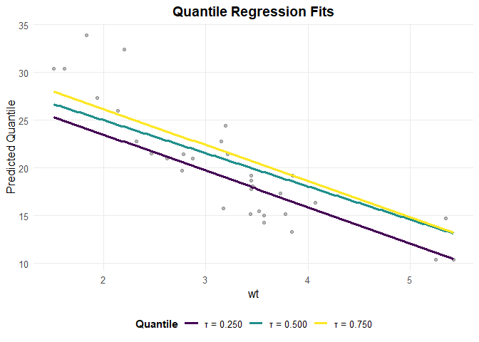

```r
# Multi-panel coefficient plot
plot(fit_multi, type = "fit", use_ggplot = TRUE, ncol = 3, combine = TRUE)
```

Alternatively, the user may choose to display separate panels for each quantile by setting `combine = FALSE`.

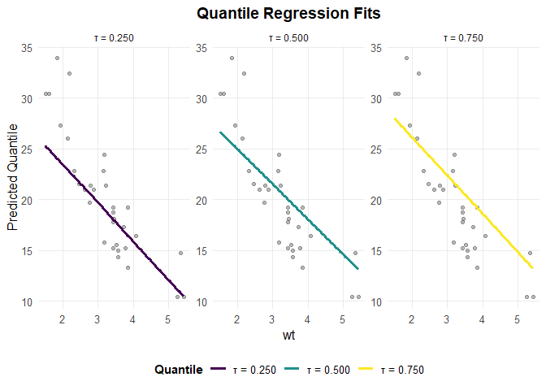

```r
# Multi-panel coefficient plot
plot(fit_multi, type = "fit", use_ggplot = TRUE, ncol = 3, combine = FALSE)
```

## Comparison with bayesQR for the MCMC algorithms and EM algorithm

### Simulation Study

We conduct a simulation study to illustrate **bayesQRsurvey** capabilities and compare with **bayesQR** using three different sampling designs: Poisson sampling, stratified sampling, and systematic sampling. Each design simulates complex survey data with known population parameters.

The used simulation functions can be found in the data-raw folder simulation.R file

#### Simulation Execution

We run the simulation function and obtain the following values

```r
# Simulation parameters
set.seed(42)
N <- 10000  # Population size
n <- 500    # Sample size
n_est <- 5  # Number of strata for stratified sampling
quantiles <- c(0.25, 0.5, 0.75)

# True population parameters
true_beta <- c(2, 1.5)  # Intercept and slope

# Create simulation parameters table
sim_params <- data.frame(
  Parameter = c("Population size", "Sample size", "Number of strata", "Quantiles", "True β₀", "True β₁"),
  Value = c(N, n, n_est, paste(quantiles, collapse = ", "), true_beta[1], true_beta[2])
)

knitr::kable(sim_params, caption = "Simulation Study Parameters")
```

Simulation Study Parameters

| Parameter | Value |
| --- | --- |
| Population size | 10000 |
| Sample size | 500 |
| Number of strata | 5 |
| Quantiles | 0.25, 0.5, 0.75 |
| True β₀ | 2 |
| True β₁ | 1.5 |

```r
# Generate data for each sampling design
data_poi <- artificial_data_poi(N, n)
data_est <- artificial_data_est(N, n, n_est)
data_sys <- artificial_data_sys(N, n)

# Create data frames for analysis
create_dataframe <- function(sim_data) {
  data.frame(
    y = sim_data$sample_data,
    x = sim_data$x_matrix[, 2],  # Remove intercept column
    weights = sim_data$weights
  )
}

df_poi <- create_dataframe(data_poi)
df_est <- create_dataframe(data_est)
df_sys <- create_dataframe(data_sys)

# Sample sizes summary
sample_sizes <- data.frame(
  Design = c("Poisson", "Stratified", "Systematic"),
  Sample_Size = c(nrow(df_poi), nrow(df_est), nrow(df_sys))
)

knitr::kable(sample_sizes, caption = "Sample Sizes After Sampling", col.names = c("Design", "Sample Size"))
```

Sample Sizes After Sampling

| Design | Sample Size |
| --- | --- |
| Poisson | 534 |
| Stratified | 500 |
| Systematic | 500 |

#### Method Comparison

```r
# Function to fit models and extract coefficients
fit_and_compare <- function(data, design_name) {
  # Common MCMC settings (reduced for vignette)
  niter <- 5000
  burnin <- 2500

  # bayesQR
  fit_bqr <- bayesQR::bayesQR(
    y ~ x,
    data = data,
    quantile = quantiles,
    ndraw = niter - burnin,
    keep = 1
  )

  # bayesQRsurvey - ALD method
  fit_ald <- bqr.svy(
    y ~ x,
    data = data,
    weights = data$weights,
    quantile = quantiles,
    method = "ald",
    niter = niter,
    burnin = burnin,
    verbose  = FALSE
  )

  # bayesQRsurvey - Score method
  fit_score <- bqr.svy(
    y ~ x,
    data = data,
    weights = data$weights,
    quantile = quantiles,
    method = "score",
    niter = niter,
    burnin = burnin,
    verbose  = FALSE
  )

  # bayesQRsurvey - Approximate method
  fit_approx <- bqr.svy(
    y ~ x,
    data = data,
    weights = data$weights,
    quantile = quantiles,
    method = "approximate",
    niter = niter,
    burnin = burnin,
    verbose  = FALSE
  )

  # Extract coefficient estimates
  coef_bqr <- sapply(1:3, function(i) colMeans(fit_bqr[[i]]$betadraw))
  coef_ald <- fit_ald$beta
  coef_score <- fit_score$beta
  coef_approx <- fit_approx$beta

  # Calculate bias and RMSE
  calculate_metrics <- function(estimates, true_vals) {
    bias <- estimates - matrix(rep(true_vals, 3), nrow = 2, ncol = 3)
    rmse <- sqrt(colMeans(bias^2))
    list(bias = bias, rmse = rmse, estimates = estimates)
  }

  metrics_bqr <- calculate_metrics(coef_bqr, true_beta)
  metrics_ald <- calculate_metrics(coef_ald, true_beta)
  metrics_score <- calculate_metrics(coef_score, true_beta)
  metrics_approx <- calculate_metrics(coef_approx, true_beta)

  return(list(
    bayesQR = metrics_bqr,
    ALD = metrics_ald,
    Score = metrics_score,
    Approximate = metrics_approx
  ))
}

# Run comparison for each design
results_poi <- fit_and_compare(df_poi, "Poisson")
results_est <- fit_and_compare(df_est, "Stratified")
results_sys <- fit_and_compare(df_sys, "Systematic")
```

#### Simulation Results

```r
# Poisson Sampling
for (q_idx in seq_along(quantiles)) {
  tau_val <- quantiles[q_idx]
  table_result <- create_results_table(
    results_poi, "Poisson", q_idx, tau_val
  )
  print(knitr::kable(
    table_result, digits = 4,
    caption = paste("Poisson Sampling - τ =", tau_val)
  ))
}
```

Poisson Sampling - τ = 0.25

| Method | Intercept | Slope |
| --- | --- | --- |
| True Values | 2.0000 | 1.5000 |
| bayesQR | 1.9092 | 1.3008 |
| ALD | 1.6628 | 1.3651 |
| Score | 1.6760 | 1.2313 |
| Approximate | 1.6748 | 1.2321 |

Poisson Sampling - τ = 0.5

| Method | Intercept | Slope |
| --- | --- | --- |
| True Values | 2.0000 | 1.5000 |
| bayesQR | 2.3707 | 1.4352 |
| ALD | 2.1408 | 1.4983 |
| Score | 2.1237 | 1.4820 |
| Approximate | 2.1234 | 1.4825 |

Poisson Sampling - τ = 0.75

| Method | Intercept | Slope |
| --- | --- | --- |
| True Values | 2.0000 | 1.5000 |
| bayesQR | 3.0358 | 1.3903 |
| ALD | 2.6539 | 1.4852 |
| Score | 2.6986 | 1.4824 |
| Approximate | 2.6968 | 1.4838 |

```r
# Stratified Sampling
for (q_idx in seq_along(quantiles)) {
  tau_val <- quantiles[q_idx]
  table_result <- create_results_table(
    results_est, "Stratified", q_idx, tau_val
  )
  print(knitr::kable(
    table_result, digits = 4,
    caption = paste("Stratified Sampling - τ =", tau_val)
  ))
}
```

Stratified Sampling - τ = 0.25

| Method | Intercept | Slope |
| --- | --- | --- |
| True Values | 2.0000 | 1.5000 |
| bayesQR | 1.4433 | 1.5779 |
| ALD | 1.3217 | 1.5691 |
| Score | 1.2925 | 1.5599 |
| Approximate | 1.2793 | 1.5668 |

Stratified Sampling - τ = 0.5

| Method | Intercept | Slope |
| --- | --- | --- |
| True Values | 2.0000 | 1.5000 |
| bayesQR | 2.2061 | 1.4838 |
| ALD | 1.8633 | 1.6120 |
| Score | 1.8448 | 1.6100 |
| Approximate | 1.8426 | 1.6111 |

Stratified Sampling - τ = 0.75

| Method | Intercept | Slope |
| --- | --- | --- |
| True Values | 2.0000 | 1.5000 |
| bayesQR | 2.8812 | 1.4801 |
| ALD | 2.5164 | 1.5360 |
| Score | 2.5585 | 1.5515 |
| Approximate | 2.5563 | 1.5502 |

```r
# Systematic Sampling
for (q_idx in seq_along(quantiles)) {
  tau_val <- quantiles[q_idx]
  table_result <- create_results_table(
    results_sys, "Systematic", q_idx, tau_val
  )
  print(knitr::kable(
    table_result, digits = 4,
    caption = paste("Systematic Sampling - τ =", tau_val)
  ))
}
```

Systematic Sampling - τ = 0.25

| Method | Intercept | Slope |
| --- | --- | --- |
| True Values | 2.0000 | 1.5000 |
| bayesQR | 1.7098 | 1.4487 |
| ALD | 1.4035 | 1.5937 |
| Score | 1.3301 | 1.6013 |
| Approximate | 1.3515 | 1.5869 |

Systematic Sampling - τ = 0.5

| Method | Intercept | Slope |
| --- | --- | --- |
| True Values | 2.0000 | 1.5000 |
| bayesQR | 2.3127 | 1.4671 |
| ALD | 2.1208 | 1.5018 |
| Score | 2.0686 | 1.5094 |
| Approximate | 2.0847 | 1.4998 |

Systematic Sampling - τ = 0.75

| Method | Intercept | Slope |
| --- | --- | --- |
| True Values | 2.0000 | 1.5000 |
| bayesQR | 2.9191 | 1.4580 |
| ALD | 2.5350 | 1.5787 |
| Score | 2.5622 | 1.5866 |
| Approximate | 2.5398 | 1.6011 |

For the EM algorithm

```r
library(pracma)
library(dplyr)
library(knitr)

#if (!exists("rbern")) rbern <- function(n, p) rbinom(n, 1, p)

make_mo_dataset <- function(design = c("poi","est","sys"),
                            N = 5000, n = 400, n_est = 4,
                            beta1 = c(2, 1.5),
                            beta2 = c(-1, 0.8),
                            sd2   = 1) {
  design <- match.arg(design)
  if (design == "poi") {
    s <- artificial_data_poi(N, n)
    X <- s$x_matrix
    y1 <- as.numeric(s$sample_data)
    w  <- as.numeric(s$weights)
  } else if (design == "est") {
    s <- artificial_data_est(N, n, n_est)
    X <- s$x_matrix
    y1 <- as.numeric(s$sample_data)
    w  <- as.numeric(s$weights)
  } else {
    s <- artificial_data_sys(N, n)
    X <- s$x_matrix
    y1 <- as.numeric(s$sample_data)
    w  <- as.numeric(s$weights)
  }

  y2 <- as.numeric(X %*% beta2 + rnorm(nrow(X), sd = sd2))

  df <- data.frame(
    y1 = y1,
    y2 = y2,
    x1 = X[, 2]
  )

  B <- cbind(beta1, beta2)

  list(data = df, w = w, X = X, B = B)
}
```

```r
run_mo_sim <- function(design = "poi",
                       N = 5000, n = 400, n_est = 4,
                       taus = c(0.25, 0.5, 0.75),
                       n_dir = 10,
                       max_iter = 500, verbose = FALSE,
                       keep_intercept = FALSE) {
  sim <- make_mo_dataset(design = design, N = N, n = n, n_est = n_est)
  df  <- sim$data
  w   <- sim$w
  B   <- sim$B
  d   <- 2
  p   <- 2

  set.seed(123)
  U <- matrix(NA_real_, d, n_dir)
  for (k in 1:n_dir) {
    uk <- rnorm(d)
    U[, k] <- uk / sqrt(sum(uk^2))
  }

  pr_mo <- prior(
    beta_x_mean = rep(0, p),
    beta_x_cov  = diag(1e6, p),
    sigma_shape = 0.001,
    sigma_rate  = 0.001,
    beta_y_mean = 0,
    beta_y_cov  = 1
  )

  fit <- mo.bqr.svy(
    cbind(y1, y2) ~ x1,
    data     = df,
    weights  = w,
    quantile = taus,
    U        = U,
    max_iter = max_iter,
    verbose  = verbose,
    prior    = pr_mo
  )

  qlab <- paste0("q", taus)
  tau_pick <- "q0.5"
  stopifnot(tau_pick %in% qlab)

  comp <- do.call(rbind, lapply(1:n_dir, function(k) {
    Bu <- as.numeric(B %*% U[, k])
    beta_hat <- fit$fit[[tau_pick]]$directions[[k]]$beta[1:p]

    if (keep_intercept) {
      data.frame(
        dir      = k,
        u1       = round(U[1, k], 4),
        u2       = round(U[2, k], 4),
        true_Int = Bu[1],
        true_x1  = Bu[2],
        hat_Int  = beta_hat[1],
        hat_x1   = beta_hat[2],
        row.names = NULL
      )
    } else {
      data.frame(
        dir     = k,
        u1      = round(U[1, k], 4),
        u2      = round(U[2, k], 4),
        true_x1 = Bu[2],
        hat_x1  = beta_hat[2],
        row.names = NULL
      )
    }
  }))

  list(fit = fit, U = U, B = B, comparison_tau0.5 = comp)
}

# Run simulation
out_poi2 <- run_mo_sim(
  design = "poi", N = 5000, n = 400, n_est = 4,
  taus = c(0.25, 0.5, 0.75), n_dir = 10,
  max_iter = 400, keep_intercept = TRUE
)
```

```r
kable(out_poi2$comparison_tau0.5,
      digits = 3,
      caption = "Directional comparison (tau = 0.5): true projected coefficients Bu vs. estimates from mo.bqr.svy.")
```

Directional comparison (tau = 0.5): true projected coefficients Bu vs. estimates from mo.bqr.svy.

| dir | u1 | u2 | true_Int | true_x1 | hat_Int | hat_x1 |
| --- | --- | --- | --- | --- | --- | --- |
| 1 | -0.925 | -0.380 | -1.470 | -1.691 | -1.839 | -1.340 |
| 2 | 0.999 | 0.045 | 1.953 | 1.535 | 2.237 | 1.330 |
| 3 | 0.075 | 0.997 | -0.847 | 0.910 | -0.472 | 0.876 |
| 4 | 0.342 | -0.940 | 1.624 | -0.238 | 1.367 | -0.279 |
| 5 | -0.839 | -0.544 | -1.133 | -1.694 | -1.441 | -1.357 |
| 6 | 0.959 | 0.282 | 1.637 | 1.665 | 2.050 | 1.353 |
| 7 | 0.964 | 0.266 | 1.662 | 1.659 | 2.046 | 1.361 |
| 8 | -0.297 | 0.955 | -1.549 | 0.318 | -1.189 | 0.301 |
| 9 | 0.245 | -0.969 | 1.460 | -0.407 | 1.157 | -0.365 |
| 10 | 0.829 | -0.559 | 2.217 | 0.797 | 2.290 | 0.705 |

### Prostate Dataset

These data come from a study that examined the correlation between the level of prostate specific antigen and a number of clinical measures in men who were about to receive a radical prostatectomy. It is a data frame with 97 rows and 9 columns and is loaded form the bayesQR package.

```r
library(bayesQRsurvey)
library(bayesQR)

# Load Prostate dataset
data(Prostate, package = "bayesQR")

# Center covariates (subtract mean, don't scale)
covars <- Prostate[, colnames(Prostate) != "lpsa"]
covars_centered <- as.data.frame(scale(covars, center = TRUE, scale = FALSE))

# Combined dataset with centered covariates
Prostate_centered <- cbind(lpsa = Prostate$lpsa, covars_centered)

# Design matrix (includes intercept automatically)
X <- model.matrix(lpsa ~ ., data = Prostate_centered)
y <- Prostate_centered$lpsa
w <- rep(1, length(y))  # Equal weights

# Display dataset summary
dataset_info <- data.frame(
  Information = c("Observations", "Coefficients", "Response Variable", "Equal Weights"),
  Value = c(nrow(Prostate_centered), ncol(X), "lpsa (log prostate-specific antigen)", "Yes")
)

knitr::kable(dataset_info, caption = "Prostate Dataset Summary")
```

Prostate Dataset Summary

| Information | Value |
| --- | --- |
| Observations | 97 |
| Coefficients | 9 |
| Response Variable | lpsa (log prostate-specific antigen) |
| Equal Weights | Yes |

```r
predictors_info <- data.frame(
  Predictor = colnames(X),
  Description = c("Intercept", paste("Centered", colnames(X)[-1]))
)

knitr::kable(predictors_info, caption = "Predictor Variables")
```

Predictor Variables

| Predictor | Description |
| --- | --- |
| (Intercept) | Intercept |
| lcavol | Centered lcavol |
| lweight | Centered lweight |
| age | Centered age |
| lbph | Centered lbph |
| svi | Centered svi |
| lcp | Centered lcp |
| gleason | Centered gleason |
| pgg45 | Centered pgg45 |

```r
# Prior for bayesQRsurvey (all methods)
prior_tbw <- bayesQRsurvey::prior(
  beta_x_mean = rep(0, ncol(X)),
  beta_x_cov  = diag(1e6, ncol(X)),
  sigma_shape = 0.001,
  sigma_rate  = 0.001
)


# Prior for bayesQR
prior_bqr <- bayesQR::prior(
  lpsa ~ ., data = Prostate_centered,
  beta0 = rep(0, ncol(X)),
  V0 = diag(1e6, ncol(X))  # Same vague prior
)
```

#### bayesQR (Reference Method)

```r
set.seed(12345)

fit_bqr <- bayesQR(
  lpsa ~ .,
  data = Prostate_centered,
  quantile = c(0.25, 0.5, 0.75),
  ndraw = 5000,
  prior = prior_bqr,
  keep = 5
)

taus <- c(0.25, 0.5, 0.75)

coef_mat <- do.call(rbind, lapply(seq_along(taus), function(i) {
  draws_i <- fit_bqr[[i]][["betadraw"]]
  colnames(draws_i) <- colnames(X)
  as.numeric(colMeans(draws_i, na.rm = TRUE))  # vector numérico
}))

rownames(coef_mat) <- paste0("tau = ", taus)
colnames(coef_mat) <- colnames(X)
```

#### bayesQRsurvey Method 1: ALD (Asymmetric Laplace Distribution)

```r
set.seed(12345)

fit_ald <- bqr.svy(
  lpsa ~ lcavol + lweight + age + lbph + svi + lcp + gleason + pgg45,
  data     = Prostate_centered,
  quantile = c(0.25, 0.5, 0.75),
  method   = "ald",
  prior    = prior_tbw,
  niter    = 50000,
  burnin   = 25000,
  thin     = 5,
  verbose  = TRUE
)

coef_ald <- fit_ald$beta
```

#### bayesQRsurvey Method 2: Score Likelihood

```r
set.seed(12345)

fit_score <- bqr.svy(
  lpsa ~ lcavol + lweight + age + lbph + svi + lcp + gleason + pgg45,
  data     = Prostate_centered,
  quantile = c(0.25, 0.5, 0.75),
  method   = "score",
  prior    = prior_tbw,
  niter    = 50000,
  burnin   = 25000,
  thin     = 5,
  verbose  = TRUE
)

coef_score <- fit_score$beta
```

#### bayesQRsurvey Method 3: Approximate Method

```r
set.seed(12345)

fit_approximate <- bqr.svy(
  lpsa ~ lcavol + lweight + age + lbph + svi + lcp + gleason + pgg45,
  data     = Prostate_centered,
  quantile = c(0.25, 0.5, 0.75),
  method   = "approximate",
  prior    = prior_tbw,
  niter    = 50000,
  burnin   = 25000,
  thin     = 5,
  verbose  = TRUE
)

coef_approximate <- fit_approximate$beta
```

#### Results comparison

```r
make_results_table <- function(q_index, q_label) {
  coef_bqr   <- coef_mat[q_index, ]
  coef_ald   <- fit_ald[["beta"]][, q_index]
  coef_score <- fit_score[["beta"]][, q_index]
  coef_approx<- fit_approximate[["beta"]][, q_index]

  vars <- names(coef_bqr)

  results <- data.frame(
    Method = c("bayesQR", "bayesQRsurvey - ALD", "bayesQRsurvey - Score", "bayesQRsurvey - Approximate"),
    t(sapply(list(coef_bqr, coef_ald, coef_score, coef_approx), function(coefs) coefs[vars]))
  )

  colnames(results) <- c("Method", vars)

  knitr::kable(results, digits = 3, caption = paste("Coefficient Estimates at quantile", q_label))
}
```

##### 25th quantile

```r
make_results_table(1, 0.25)
```

Coefficient Estimates at quantile 0.25

| Method | (Intercept) | lcavol | lweight | age | lbph | svi | lcp | gleason | pgg45 |
| --- | --- | --- | --- | --- | --- | --- | --- | --- | --- |
| bayesQR | 1.927 | 0.629 | 0.604 | -0.016 | 0.115 | 0.688 | -0.212 | -0.021 | 0.009 |
| bayesQRsurvey - ALD | 2.111 | 0.695 | 0.683 | -0.014 | 0.114 | 0.780 | -0.237 | -0.060 | 0.011 |
| bayesQRsurvey - Score | 2.072 | 0.703 | 0.690 | -0.015 | 0.117 | 0.695 | -0.234 | -0.018 | 0.011 |
| bayesQRsurvey - Approximate | 2.077 | 0.692 | 0.708 | -0.012 | 0.106 | 0.793 | -0.231 | -0.038 | 0.011 |

##### 50th quantile

```r
make_results_table(2, 0.50)
```

Coefficient Estimates at quantile 0.5

| Method | (Intercept) | lcavol | lweight | age | lbph | svi | lcp | gleason | pgg45 |
| --- | --- | --- | --- | --- | --- | --- | --- | --- | --- |
| bayesQR | 2.473 | 0.567 | 0.516 | -0.022 | 0.134 | 0.806 | -0.141 | 0.042 | 0.007 |
| bayesQRsurvey - ALD | 2.432 | 0.525 | 0.554 | -0.026 | 0.156 | 0.832 | -0.116 | 0.208 | 0.003 |
| bayesQRsurvey - Score | 2.438 | 0.528 | 0.541 | -0.024 | 0.149 | 0.862 | -0.113 | 0.231 | 0.002 |
| bayesQRsurvey - Approximate | 2.441 | 0.524 | 0.534 | -0.024 | 0.150 | 0.869 | -0.109 | 0.231 | 0.002 |

##### 75th quantile

```r
make_results_table(3, 0.75)
```

Coefficient Estimates at quantile 0.75

| Method | (Intercept) | lcavol | lweight | age | lbph | svi | lcp | gleason | pgg45 |
| --- | --- | --- | --- | --- | --- | --- | --- | --- | --- |
| bayesQR | 3.033 | 0.549 | 0.398 | -0.020 | 0.112 | 0.893 | -0.041 | 0.065 | 0.003 |
| bayesQRsurvey - ALD | 2.894 | 0.565 | 0.146 | -0.013 | 0.111 | 0.864 | -0.065 | -0.109 | 0.007 |
| bayesQRsurvey - Score | 2.943 | 0.479 | 0.478 | -0.021 | 0.075 | 0.947 | 0.000 | -0.059 | 0.004 |
| bayesQRsurvey - Approximate | 2.931 | 0.563 | 0.115 | -0.015 | 0.115 | 0.941 | -0.057 | -0.100 | 0.006 |